# Individual Project 1

Nikko Bernardo BSIT-2A

2022-12-08

#Individual Project 1

#Packages that will be needed

```r
library("twitteR")
library(dplyr)
library(tidyr)
```

```r
library("plotly")
library(ggplot2)
library(RColorBrewer)
library(tidytext)
library(rtweet)
library(tm)
library(slam)
library(wordcloud)
library(wordcloud2)
library(corpus)
```

#1. Extract from twitter using your developer’s credentials. Choose any keyword you want.

#Set-up credentials

```r
CONSUMER_SECRET <-"cPjVH3WbIzgg5TnV8co99GRjSrmAPH9xHGLvvH5HTtprJQaitO"
CONSUMER_KEY <-"anRJmejG8LPugdGrtqe8naWQk"
ACCESS_SECRET <- "A4vhfNX6RX5AhAZQrI3gpasRBGw2VHbmAm5XMdm0YrNov"
ACCESS_TOKEN <- "1596107281610858498-sSmW933erENXHM1POaXUjSLhVQ0yAH"
```

#connect to twitter app

```r
setup_twitter_oauth(consumer_key = CONSUMER_KEY,
                    consumer_secret = CONSUMER_SECRET,
                    access_token = ACCESS_TOKEN,
                    access_secret = ACCESS_SECRET)
```

```
## [1] "Using direct authentication"
```

#Getting a data #it would take few minutes to load which depend the number of data you need #but when you already save this data as a file you can skip this part.

```r
trendTweets <- searchTwitter("#music -filter:retweets",
                             n = 10000,
                             lang = "en",
                              since = "2022-12-12",
                             until = "2022-12-18",
                             retryOnRateLimit=120)
```

```
## [1] "Rate limited .... blocking for a minute and retrying up to 119 times ..."
```

```r
trendTweets
```

[output not shown]

[output cut: 29944 more lines]

[output not shown]

```r
save(trendTweets, file = "trendSteets.Rdata")
```

```r
head(trendTweets)
```

```
## [[1]]
## [1] "trashdiscoradio: In case you missed Show 373 (Top 20 Most Played Artists), here’s the list of songs played:\n\nhttps://t.co/gxvpJFwAub… https://t.co/kjY572zfAr"
##
## [[2]]
## [1] "Thisisthem3: Posted a new song: \"Girls Wish They Were You (So Many)\" https://t.co/V28Fx40eZY #music https://t.co/7xdEtsEvmZ"
##
## [[3]]
## [1] "wxmradio: Now playing: Prince Royce - Carita de inocente  #NowPlaying #música #escucha #hot #music Listen live:… https://t.co/BITVsDTYIm"
##
## [[4]]
## [1] "RDTVF: #NowPlaying 🎶🎵 On 🐦@RDTVF : \n\n🎶📀🎶🎵 ΜΛIƆO 🇺🇸\n🎶Palm Springs 🎶 \n🐦 @MaicoTCO @RetroSynthMusic\n\n#rtitbot #TuneIn📡 🌍🌏… https://t.co/Cxl3j0FfuW"
##
## [[5]]
## [1] "RadioFlipside: #NowPlaying Flipside - Welcome, Stay A While\nThe new Radio Flipside app is on the Apple App Store… https://t.co/JPHIxv58Yk"
##
## [[6]]
## [1] "ChordLanguage: #Chord #space_time is expressed by chord (#quantum spectrum, #strings) and has space-time duality (… https://t.co/MPB1MhuOZ7"
```

#Convert Data into data Frame :)

```r
trendTweetsDF <- twListToDF(trendTweets)
class(trendTweetsDF)
```

```
## [1] "data.frame"
```

```r
names(trendTweetsDF)
```

```
##  [1] "text"          "favorited"     "favoriteCount" "replyToSN"
##  [5] "created"       "truncated"     "replyToSID"    "id"
##  [9] "replyToUID"    "statusSource"  "screenName"    "retweetCount"
## [13] "isRetweet"     "retweeted"     "longitude"     "latitude"
```

```r
View(trendTweetsDF)
head(trendTweetsDF)[1:5]
```

```
##                                                                                                                                             text
## 1 In case you missed Show 373 (Top 20 Most Played Artists), here’s the list of songs played:\n\nhttps://t.co/gxvpJFwAub… https://t.co/kjY572zfAr
## 2                                 Posted a new song: "Girls Wish They Were You (So Many)" https://t.co/V28Fx40eZY #music https://t.co/7xdEtsEvmZ
## 3                 Now playing: Prince Royce - Carita de inocente  #NowPlaying #música #escucha #hot #music Listen live:… https://t.co/BITVsDTYIm
## 4 #NowPlaying 🎶🎵 On 🐦@RDTVF : \n\n🎶📀🎶🎵 ΜΛIƆO 🇺🇸\n🎶Palm Springs 🎶 \n🐦 @MaicoTCO @RetroSynthMusic\n\n#rtitbot #TuneIn📡 🌍🌏… https://t.co/Cxl3j0FfuW
## 5                    #NowPlaying Flipside - Welcome, Stay A While\nThe new Radio Flipside app is on the Apple App Store… https://t.co/JPHIxv58Yk
## 6                   #Chord #space_time is expressed by chord (#quantum spectrum, #strings) and has space-time duality (… https://t.co/MPB1MhuOZ7
##   favorited favoriteCount replyToSN             created
## 1     FALSE             4      <NA> 2022-12-17 23:59:56
## 2     FALSE             0      <NA> 2022-12-17 23:59:51
## 3     FALSE             0      <NA> 2022-12-17 23:59:47
## 4     FALSE             0      <NA> 2022-12-17 23:59:43
## 5     FALSE             0      <NA> 2022-12-17 23:59:42
## 6     FALSE             0      <NA> 2022-12-17 23:59:30
```

```r
head(trendTweetsDF$text)[1:5]
```

```
## [1] "In case you missed Show 373 (Top 20 Most Played Artists), here’s the list of songs played:\n\nhttps://t.co/gxvpJFwAub… https://t.co/kjY572zfAr"
## [2] "Posted a new song: \"Girls Wish They Were You (So Many)\" https://t.co/V28Fx40eZY #music https://t.co/7xdEtsEvmZ"
## [3] "Now playing: Prince Royce - Carita de inocente  #NowPlaying #música #escucha #hot #music Listen live:… https://t.co/BITVsDTYIm"
## [4] "#NowPlaying 🎶🎵 On 🐦@RDTVF : \n\n🎶📀🎶🎵 ΜΛIƆO 🇺🇸\n🎶Palm Springs 🎶 \n🐦 @MaicoTCO @RetroSynthMusic\n\n#rtitbot #TuneIn📡 🌍🌏… https://t.co/Cxl3j0FfuW"
## [5] "#NowPlaying Flipside - Welcome, Stay A While\nThe new Radio Flipside app is on the Apple App Store… https://t.co/JPHIxv58Yk"
```

#Save the Data #Saving the data into a file

```r
save(trendTweetsDF,file = "trendingTweetsDF.Rdata")
load(file = "trendingTweetsDF.Rdata")
```

#Checking for missing values in a data frame

```r
sapply(trendTweetsDF, function(x) sum(is.na(x)))
```

```
##          text     favorited favoriteCount     replyToSN       created
##             0             0             0          9760             0
##     truncated    replyToSID            id    replyToUID  statusSource
##             0          9824             0          9760             0
##    screenName  retweetCount     isRetweet     retweeted     longitude
##             0             0             0             0          9970
##      latitude
##          9970
```

#Subsetting using the dplyr()package

```r
tweetsDF <- trendTweetsDF %>%
  select(screenName,text,created,statusSource)
```

```r
save(tweetsDF, file = "tweetsDF.Rdata")
load(file = "tweetsDf.Rdata")
```

##3. Plot the time series from the date created. with legends.

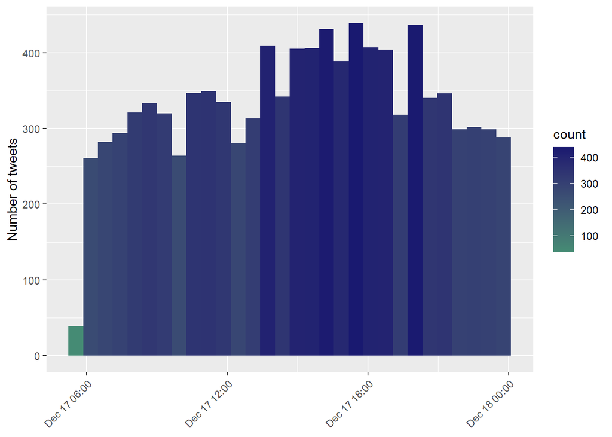

```r
ggplot(data = tweetsDF, aes(x = created), fill = tweetsDF) +
  geom_histogram(aes(fill = ..count..)) +
  theme(legend.position="right",
        axis.title.x = element_blank(),
        axis.text.x = element_text(angle = 45, hjust = 1)) +
  xlab("Time") + ylab("Number of tweets") +
  scale_fill_gradient(low = "aquamarine4", high = "midnightblue")
```

##4. Plot a graph (any graph you want) based on the type of device - found in Source #- that the user use. Include the legends.

```r
encodeSource <- function(x) {
  if(grepl(">Twitter for iPhone</a>", x)){
    "iphone"
  }else if(grepl(">Twitter for iPad</a>", x)){
    "ipad"
  }else if(grepl(">Twitter for Android</a>", x)){
    "android"
  } else if(grepl(">Twitter Web Client</a>", x)){
    "Web"
  } else if(grepl(">Twitter for Windows Phone</a>", x)){
    "windows phone"
  }else if(grepl(">dlvr.it</a>", x)){
    "dlvr.it"
  }else if(grepl(">IFTTT</a>", x)){
    "ifttt"
  }else if(grepl(">Facebook</a>", x)){
    "facebook"
  }else {
    "others"
  }
}


tweetsDF$tweetSource = sapply(tweetsDF$statusSource,
                              encodeSource)

tweet_appSource <- tweetsDF %>%
  select(tweetSource) %>%
  group_by(tweetSource) %>%
  summarize(count=n()) %>%
  arrange(desc(count))

Source_subset <- subset(tweet_appSource,count >10)
```

```r
dataDF <- data.frame(
  category = tweet_appSource$tweetSource,
  count = tweet_appSource$count
)

dataDF$fraction = dataDF$count / sum(dataDF$count)
dataDF$percentage = dataDF$count / sum(dataDF$count) * 100
dataDF$ymax = cumsum(dataDF$fraction)
dataDF$ymin = c(0, head(dataDF$ymax, n=-1))
dataDF$roundP = round(dataDF$percentage, digits = 2)
```

#plotting using geom_bar() - bar graph

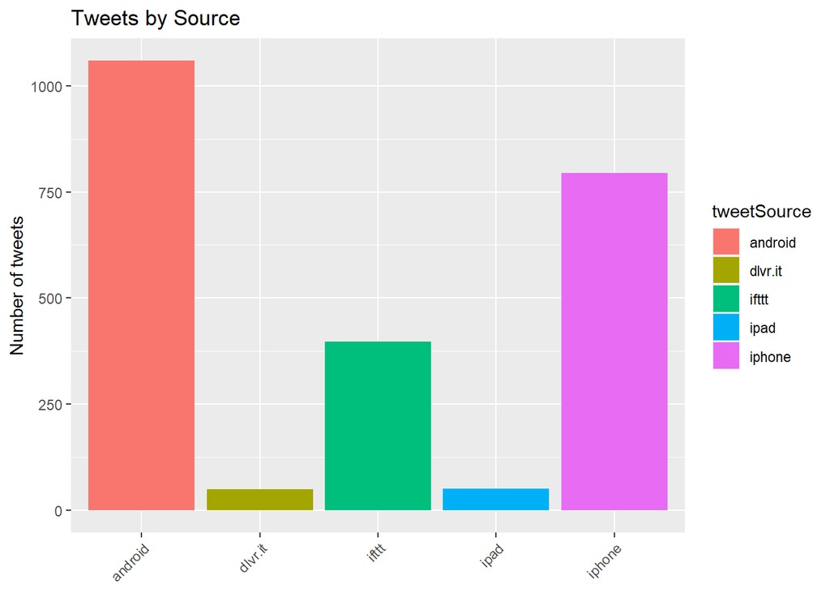

```r
ggplot(tweetsDF[tweetsDF$tweetSource != 'others',], aes(tweetSource, fill = tweetSource)) +
  geom_bar() +
  theme(legend.position="right",
        axis.title.x = element_blank(),
        axis.text.x = element_text(angle = 45, hjust = 1)) +
  ylab("Number of tweets") +
  ggtitle("Tweets by Source")
```

##5. Create a wordcloud from the screenName

#Using wordcloud() package but using a shape pentagon

```r
tweet_appScreen <- tweetsDF %>%
  select(screenName) %>%
  group_by(screenName) %>%
  summarize(count=n()) %>%
  arrange(desc(count))
```

#convert to Corpus

```r
namesCorpus <- Corpus(VectorSource(tweetsDF$screenName))
```

#Running the code using the wordcloud()

```r
wordcloud2(data=tweet_appScreen,
           size=0.8,
           color='random-light',
           shape = 'pentagon')
```

[interactive chart not shown]